# Intro To R

[Nao Mimoto](http://gozips.uakron.edu/~nmimoto/) - [Dept. of Statistics](http://www.uakron.edu/stat/) : [The University of Akron](http://www.uakron.edu)

Jan 16 2018

[R resource page](http://gozips.uakron.edu/~nmimoto/R/index.html)

### R is free

you can google R, or click [here](https://www.r-project.org) to go to R Project Website. Click CRAN on the left, then scroll down to choose USA: Case Western Mirror Site.

R is available for PC, Mac or Linux.

### R is popular

[This ranking](https://www.tiobe.com/tiobe-index//) says it’s 8th most popular as of Jan 2018.

Along with Python, R is the one of the major language in Machine Learning/Data Science.

It is the leading software for Statistical Analysis Software, along with SAS and JMP, which are not free.

### R and R-studio

R-studio is wrap-around built over R, and makes R interface look more like Matlab. You can also download and install R-studio for free.

You are free to use R-studio, but all in-class demo will be done on R.

## 1. Before Starting

### Know your current dir

You must know which directory you are in. To show your current directory, type below in R console.

```r
getwd()
```

If you save a dataset later, this is the folder it will be stored at.

To change your working directory, go to **Workspace Browser** on top menu.

### UA lab workaround

If you can’t add new package to your R, follow the steps below:

1. Close R.
2. Create folder called “Rlib” in your C: drive
3. Download Renviron.zip file from class web page.

   Right click, and choose “save link as…”.
4. Open downloaded zip folder, and move .Renviron file to your *desktop*.
5. Open R. You should be good to go. Try typing

```r
install.packages("forecast")
library(forecast)
data(woolyrnq)
plot(woolyrnq)
```

If you get no errors, you’re good to go.

## 2. Three ways to load data

There are three ways to load data into R,

### 2.a Some data are already inside packages

```r
library(TSA)     # loads pacckage called TSA
data(hare)       # loads the data called hare which is inside TSA
hare             # see what's inside "hare"
```

```
## Time Series:
## Start = 1905
## End = 1935
## Frequency = 1
##  [1] 50 20 20 22 27 50 55 78 70 59 28 20 15 15 25 35 65 78 82 65 26 15 10
## [24]  1  2  3 22 75 95 78 20
```

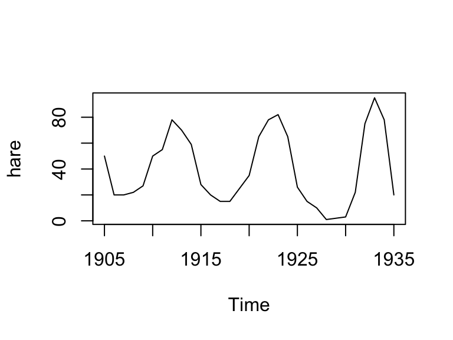

```r
plot(hare)       # plot the data
```

### 2.b Load directly from web

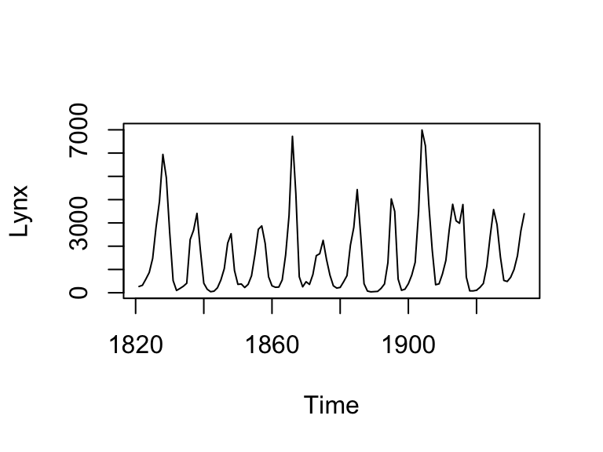

```r
d0 <- read.csv("http://gozips.uakron.edu/~nmimoto/pages/datasets/lynx.csv")
    #- Load the dataset directly from my website.
d1 <- ts(d0, start=1821, freq=1)   # turn the data into ts object
plot(d1)   # plot d1
```

If you type **d1**, R will show you what’s inside *d1*.

### 2.c From your working folder

If you have **canop.csv** downloaded to your computer, then you can do the following. Make sure the file is in your working directly.

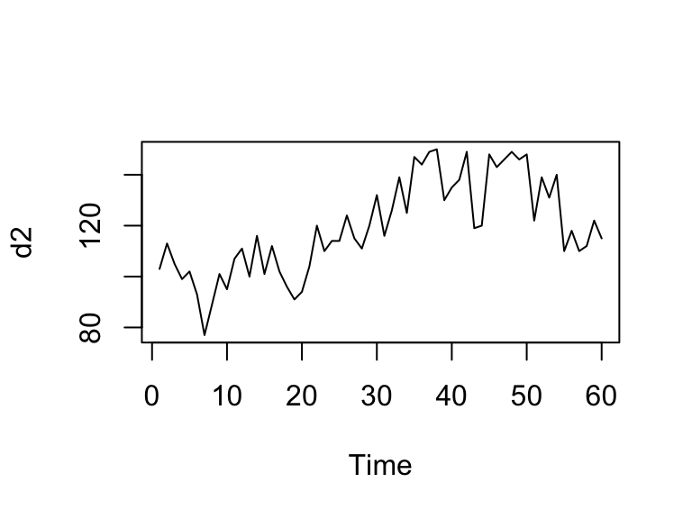

```r
d0 <- read.csv("canop.csv", header=TRUE)  # loads the data from your working directory.
d2 <- ts(d0[,2], start=1, freq=1)         # turn the data into ts object
plot(d2)   # plot d1
```

If you want to keep the dataset in different folder, but still want to load it without changing the working directory, then you can specify the entire file path insetead of just the file name “canop.csv”.

## 3. Object in R

Open up R, and type below command. You don’t have to type what comes after *#*. It is my comment explaining what that line of the code is doing.

```r
X <- 3   # This assigns 3 to object X. But you can't see it.
X = 3    # This does the same thing.
```

Now the 3 is assigned to X, you can do things like this

```r
X        # See what's inside X
```

```
## [1] 3
```

```r
X + 4    # Show the answer to this
```

```
## [1] 7
```

```r
exp(X)   # Show the answer to this
```

```
## [1] 20.08554
```

## 4. Vectors in R

R is very good at handling vectors. , and Open up R, and type below command. You don’t have to type what comes after *#*. It is my comment explaining what that line of the code is doing.

```r
X <- 3:13  # X is now a vector
X          # See what is in X
```

```
##  [1]  3  4  5  6  7  8  9 10 11 12 13
```

```r
X[5]       # See the 5th element in X
```

```
## [1] 7
```

Now that X is a vector, you can do things like this

```r
X        # See what's inside X
```

```
##  [1]  3  4  5  6  7  8  9 10 11 12 13
```

```r
X + 4    # add 4 to EACH element
```

```
##  [1]  7  8  9 10 11 12 13 14 15 16 17
```

```r
exp(X)   # take exp( ) of EACH element
```

```
##  [1]     20.08554     54.59815    148.41316    403.42879   1096.63316
##  [6]   2980.95799   8103.08393  22026.46579  59874.14172 162754.79142
## [11] 442413.39201
```

```r
X*3      # multiply 3 to EACH element
```

```
##  [1]  9 12 15 18 21 24 27 30 33 36 39
```

### 2.1 Basic Vector Functions

Now that X is a vector, you can do things like this

```r
length(X)   # length of X
```

```
## [1] 11
```

```r
min(X)      # min of X
```

```
## [1] 3
```

```r
max(X)      # max of X
```

```
## [1] 13
```

```r
sum(X)      # sum of X
```

```
## [1] 88
```

```r
mean(X)     # average of X
```

```
## [1] 8
```

For more example of commands, see [R resource page](http://gozips.uakron.edu/~nmimoto/R/index.html)